# Example showing how to run GridLMM_GWAS

`GridLMM_GWAS` and `GridLMM_GWAS_fast` implement an (approximate) linear mixed effect model GWAS that allows for multiple random effects.

A typical GWAS includes a single random effect for Kinship - accounting for non-uniform relatedness among the observations.

GxEMMA is useful in situations when there are additional sources of covariation among the observations. Examples could be:

- **Multiple measures per genotype**. In this case, an additional random effect for genotype should be included that will account for non-additive genetic effects. The typical kinship matrix only models additive covariation among lines.
  - An alternative with multiple measures is to simply average all observations per genotype into a single number and then run a standard GWAS with among-genotype kinship. If the number of observations per genotype varies, then a `weights` parameter can be added to GxEMMA with `weights = num_observations`.
- **GxE covariation**. If the goal is to test for GxE effects, then accounting for GxE covariation can be important. This can be modeled my adding an additional covariance as `diag(env) %*% K %*% diag(env)`
- **Spatial variation**. If there is spatial variation, the spatial distance can be modeled using a Kernel matrix (such as a squared-distance kernel). This is demonstrated below.

## Load data

Assuming `n` individuals, and `p` markers, the data inputs are:

- `X`. An `n x p` matrix of marker genotypes
- `map`. A SNP map describing chromosome positions of each marker
- `data`. A data.frame that includes the phenotype, and columns for all covariates and IDs necessary for the model
- `relmats`. The Kernel matrices needed for the model. The typical Genomic Relationship Matrix (GRM) Kernel can be calculated directly in the model, or can be loaded directly.

### Example data

Here is a simulated data set for running below. Each genotype is grown in a single plot. Plots are arranged in a grid in the field.

```r
n_geno = 300
n_chr = 5
n_markers_per_chr = 1000
# layout of Plots
Plots = matrix(1:n_geno,nc = 10) # rectangular array of plots
Plot_Row = row(Plots)
Plot_Col = col(Plots)
# create genotypes and randomize in field
data = data.frame(Geno = paste0('Geno',1:n_geno), Plot = sample(Plots))
data$Row = Plot_Row[data$Plot]
data$Col = Plot_Col[data$Plot]
# create marker map and random genotypes
map = expand.grid(pos = 1:n_markers_per_chr,Chr = 1:n_chr)[,2:1]
map = data.frame(snp = paste0('snp_',1:nrow(map)),map)
X = matrix(sample(c(0,2),n_geno*nrow(map),replace=T),ncol = nrow(map),dimnames = list(data$Geno,map$snp))
# simulate 1 effect per chromosome
beta = rep(0,nrow(map))
beta[(1:n_chr-1)*n_markers_per_chr + sample(1:n_markers_per_chr,n_chr)] = 1
# add background variation: modeled as small effects across all the markers
beta_background = rnorm(length(beta),0,0.1)
# create simulated data
background_h2 = 0.6 # relative contribution of the background
data$micro_env = rnorm(nrow(data)); data$micro_env = data$micro_env / sd(data$micro_env)
data$background = X %*% beta_background; data$background = data$background / sd(data$background)
data$SNPs = X %*% beta;data$SNPs = data$SNPs/sd(data$SNPs)
data$y = data$SNPs + sqrt(background_h2) * data$background + sqrt(1-background_h2) * data$micro_env
data$y = data$y/sd(data$y)
```

### Preparing the relmats

Our model will have two random effects:

1. Kinship: Typical additive relationship matrix.
2. Spatial variation.

Each random effect is modeled by including an appropriate Kernel matrix `K`. This matrix must be positive-semidefinite, and have rownames corresponding to a column of `data`

The kinship can be calculated directly by `GxEMMA_GWAS`. It will be calculated as:

```r
X_centered = sweep(X,2,colMeans(X),'-') # center marker genotypes
K = tcrossprod(X_centered) / ncol(X_centered)
rownames(K) = colnames(K) = rownames(X)
```

The spatial Kernel can be calculated using the squared distance, and a tuning parameter `h`. This parameter must be chosen. A “default” choice is given below.

```r
library(KRLS)
field = data[,c('Row','Col')]
dists = as.matrix(dist(field))
h = median(dists)
K_plot = gausskernel(field,h^2/2); diag(K_plot)=1 #
rownames(K_plot) = colnames(K_plot) = data$Plot
```

Simulate some spatial variation in the field

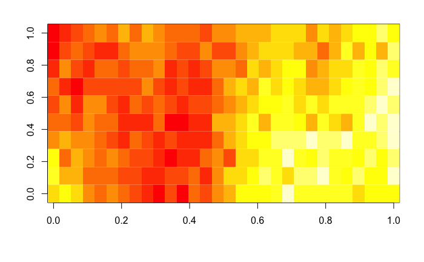

```r
h2_spatial = 0.9
s2_spatial = 1
chol_K_plot = chol(h2_spatial*K_plot + diag(1-h2_spatial,nrow(data)))
data$spatial_error = t(chol_K_plot) %*% rnorm(nrow(data),0,sqrt(s2_spatial))
field_error = 0*Plots
field_error[data$Plot] = data$spatial_error
image(field_error)
```

```r
data$y = data$y + data$spatial_error #
```

## Run GWAS

The main function for running a GWAS is `GridLMM_GWAS_fast`

```r
gwas = GridLMM_GWAS_fast(
                        formula = y~1 + (1|Geno) + (1|Plot), # the same error model is used for each marker. It is specified similarly to lmer
                        test_formula = ~1, # this is the model for each marker. ~1 means an intercept for the marker. ~1 + cov means an intercept plus a slope on `cov` for each marker
                        reduced_formula = ~0, # This is the null model for each test. ~0 means just the error model. ~1 means the null includes the intercept of the marker, but not anything additional
                        data = data, # The dataframe to look for terms from the 3 models
                        weights = NULL, # optional observation-specific weights
                        X = X, # The matrix of markers. Note: This can be of dimension n_g x p, where n_g is the number of unique genotypes.
                        X_ID = 'Geno', # The column of the data that identifies each genotype. Each level of data$Geno should match a rowname of X
                        h2_start = NULL, # An optional vector of h2s to use as starting values for each random effect in the model. If NULL, will be calculated from the error model using relmatLmer
                        h2_step = 0.01, # step size per random effect for testing alternate values of h2
                        max_steps = 100, # maximum number of steps of size h2_step to take from h2_start
                        X_map = map, # Optional. The marker positions.
                        relmat = list(Plot = K_plot), # A list of Kernel matrices for the random effects. If X_ID (here Geno) is not included in this list, then it is calculated as tcrossprod(Xc)/ncol(Xc) where Xc is the centered (and optionally scaled) X. If any random effects are described in `error_model` but not provided here, the Kernel is assumed to be the identity matrix
                        centerX = TRUE, # Should the markers be centered when calculating the GRM (only will be done if needed for calculating the GRM),
                        scaleX = FALSE, # Should the markers be scaled to have constant variance when calculating the GRM?
                        fillNAX = FALSE, # Should missing marker data be filled in with the mean allele frequency?
                        method = 'REML', # REML = Wald test, ML = LRT, BF = calculate Bayes factors
                        mc.cores = 1, # How many cores should be used for parallel processing. Unless X is large, tends to actually be faster with mc.cores = 1
                        verbose = TRUE # Should progress be printed to the screen?
)
```

```
[1] "making RRM matrix"
[1] "Estimating h2_start via null model"
[1] "step_size: 0.5, num_to_test: 3"
[1] "step_size: 0.25, num_to_test: 4"
[1] "step_size: 0.25, num_to_test: 1"
[1] "step_size: 0.125, num_to_test: 7"
[1] "step_size: 0.125, num_to_test: 1"
[1] "step_size: 0.125, num_to_test: 2"
[1] "step_size: 0.0625, num_to_test: 7"
[1] "step_size: 0.0625, num_to_test: 1"
[1] "step_size: 0.03125, num_to_test: 7"
[1] "step_size: 0.03125, num_to_test: 2"
[1] "step_size: 0.03125, num_to_test: 1"
[1] "step_size: 0.015625, num_to_test: 13"
[1] "step_size: 0.0078125, num_to_test: 16"
```

[output cut: 26 more lines]

The output is a list with two elements

```r
names(gwas)
```

```
[1] "results" "setup"
```

`setup` is parameters to re-run the model (say with a new X) like this:

```r
gwas2 = run_GWAS_fast(X,gwas$setup,h2_step = 0.01,max_steps = 100,method = 'ML')
```

```
[1] "step: 1, num_h2s: 1, num active: 5000"
[1] "step: 2, num_h2s: 8, num active: 5000"
[1] "step: 3, num_h2s: 14, num active: 4999"
[1] "step: 4, num_h2s: 16, num active: 4967"
[1] "step: 5, num_h2s: 20, num active: 4431"
[1] "step: 6, num_h2s: 24, num active: 869"
[1] "step: 7, num_h2s: 28, num active: 377"
[1] "step: 8, num_h2s: 24, num active: 190"
[1] "step: 9, num_h2s: 18, num active: 113"
[1] "step: 10, num_h2s: 15, num active: 58"
[1] "step: 11, num_h2s: 12, num active: 36"
[1] "step: 12, num_h2s: 10, num active: 24"
[1] "step: 13, num_h2s: 8, num active: 13"
[1] "step: 14, num_h2s: 8, num active: 9"
[1] "step: 15, num_h2s: 8, num active: 7"
[1] "step: 16, num_h2s: 10, num active: 4"
[1] "step: 17, num_h2s: 6, num active: 2"
[1] "step: 18, num_h2s: 7, num active: 2"
[1] "step: 19, num_h2s: 3, num active: 1"
[1] "step: 1, num_h2s: 1, num active: 1"
[1] "step: 2, num_h2s: 8, num active: 1"
[1] "step: 3, num_h2s: 5, num active: 1"
[1] "step: 4, num_h2s: 3, num active: 1"
[1] "step: 5, num_h2s: 3, num active: 1"
```

`results` contains a table of the gwas results

|  | snp | Chr | pos | Trait | X_ID | ML_logLik | Geno.ML | Plot.ML | beta.1 | beta.2 | REML_logLik | Geno.REML | Plot.REML | F.1 | n_steps | Df_X | p_value_REML |
| --- | --- | --- | --- | --- | --- | --- | --- | --- | --- | --- | --- | --- | --- | --- | --- | --- | --- |
| 1 | snp_1 | 1 | 1 | y | snp_1 | -547.7627 | 0.3195313 | 0.2041406 | 1.441709 | 0.08636449 | -543.6645 | 0.3095313 | 0.2341406 | 1.01065463 | 5 | 1 | 0.3155617 |
| 2 | snp_2 | 1 | 2 | y | snp_2 | -548.1590 | 0.2695312 | 0.2241406 | 1.433691 | 0.04350922 | -544.0193 | 0.2595312 | 0.2441406 | 0.24984186 | 2 | 1 | 0.6175553 |
| 3 | snp_3 | 1 | 3 | y | snp_3 | -548.1856 | 0.2895313 | 0.2241406 | 1.437102 | -0.03641977 | -544.0741 | 0.2795313 | 0.2441406 | 0.17671380 | 2 | 1 | 0.6745157 |
| 4 | snp_4 | 1 | 4 | y | snp_4 | -548.2671 | 0.2795313 | 0.2341406 | 1.433628 | -0.01699173 | -544.1441 | 0.2695312 | 0.2441406 | 0.03975487 | 1 | 1 | 0.8420966 |
| 5 | snp_5 | 1 | 5 | y | snp_5 | -548.2232 | 0.2895313 | 0.2241406 | 1.431105 | 0.02864302 | -544.0966 | 0.2795313 | 0.2441406 | 0.10974335 | 2 | 1 | 0.7406694 |
| 6 | snp_6 | 1 | 6 | y | snp_6 | -547.7961 | 0.2595312 | 0.2241406 | 1.436835 | -0.08405057 | -543.6806 | 0.2595312 | 0.2441406 | 0.94645945 | 2 | 1 | 0.3314112 |

You can use the `qqman` package to make a manhattan plot and qqplot:

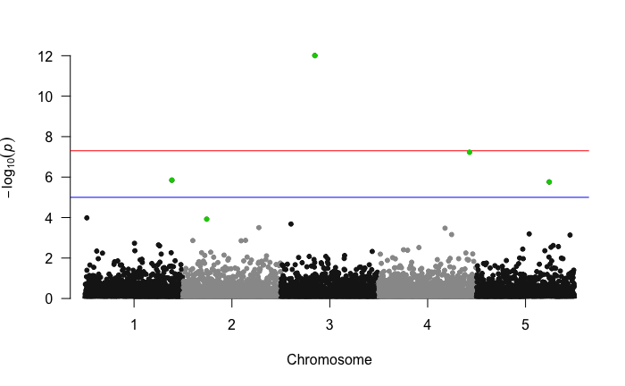

```r
library(qqman)
# manhattan plot with true SNPs highlighted
manhattan(gwas$results,'Chr','pos','p_value_REML','snp',highlight = colnames(X)[beta != 0])
```

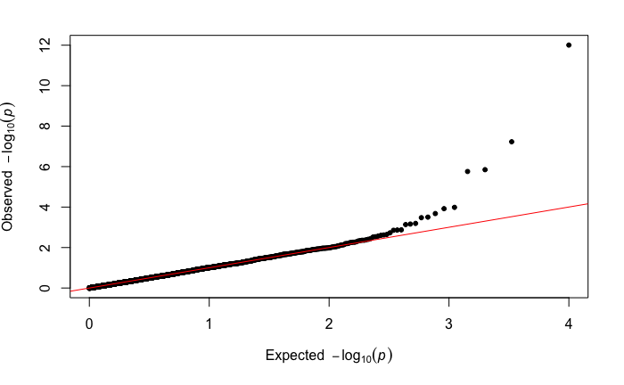

```r
# qqplot
qq(gwas$results$p_value_REML)
```

Here’s the same data run with only the GRM as a random effect

```r
gwas1 = GridLMM_GWAS_fast(
                        formula = y~1 + (1|Geno), # the same error model is used for each marker. It is specified similarly to lmer
                        test_formula = ~1, # this is the model for each marker. ~1 means an intercept for the marker. ~1 + cov means an intercept plus a slope on `cov` for each marker
                        reduced_formula = ~0, # This is the null model for each test. ~0 means just the error model. ~1 means the null includes the intercept of the marker, but not anything additional
                        data = data, # The dataframe to look for terms from the 3 models
                        weights = NULL, # optional observation-specific weights
                        X = X, # The matrix of markers. Note: This can be of dimension n_g x p, where n_g is the number of unique genotypes.
                        X_ID = 'Geno', # The column of the data that identifies each genotype. Each level of data$Geno should match a rowname of X
                        h2_start = NULL, # An optional vector of h2s to use as starting values for each random effect in the model. If NULL, will be calculated from the error model using relmatLmer
                        h2_step = 0.01, # step size per random effect for testing alternate values of h2
                        max_steps = 100, # maximum number of steps of size h2_step to take from h2_start
                        X_map = map, # Optional. The marker positions.
                        relmat = list(Plot = K_plot), # A list of Kernel matrices for the random effects. If X_ID (here Geno) is not included in this list, then it is calculated as tcrossprod(Xc)/ncol(Xc) where Xc is the centered (and optionally scaled) X. If any random effects are described in `error_model` but not provided here, the Kernel is assumed to be the identity matrix
                        centerX = TRUE, # Should the markers be centered when calculating the GRM (only will be done if needed for calculating the GRM),
                        scaleX = FALSE, # Should the markers be scaled to have constant variance when calculating the GRM?
                        fillNAX = FALSE, # Should missing marker data be filled in with the mean allele frequency?
                        method = 'REML', # Should the best model be selected by REML (if False, will be selected by ML)
                        mc.cores = 1, # How many cores should be used for parallel processing. Unless X is large, tends to actually be faster with mc.cores = 1
                        verbose = TRUE # Should progress be printed to the screen?
)
```

```
[1] "making RRM matrix"
[1] "Estimating h2_start via null model"
[1] "step_size: 0.5, num_to_test: 2"
[1] "step_size: 0.25, num_to_test: 2"
[1] "step_size: 0.125, num_to_test: 2"
[1] "step_size: 0.0625, num_to_test: 2"
[1] "step_size: 0.03125, num_to_test: 3"
[1] "step_size: 0.015625, num_to_test: 4"
[1] "step_size: 0.0078125, num_to_test: 4"
[1] "step_size: 0.00390625, num_to_test: 4"
[1] "step_size: 0.001953125, num_to_test: 4"
[1] "GridLMM_posterior h2s:"
          Geno
[1,] 0.2207031
[1] "step: 1, num_h2s: 1, num active: 5000"
```

[output cut: 22 more lines]

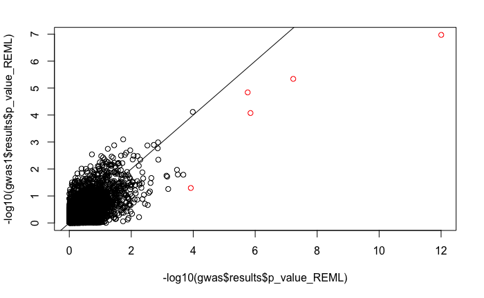

```r
plot(-log10(gwas$results$p_value_REML),-log10(gwas1$results$p_value_REML),col = (beta != 0)+1);abline(0,1)
```

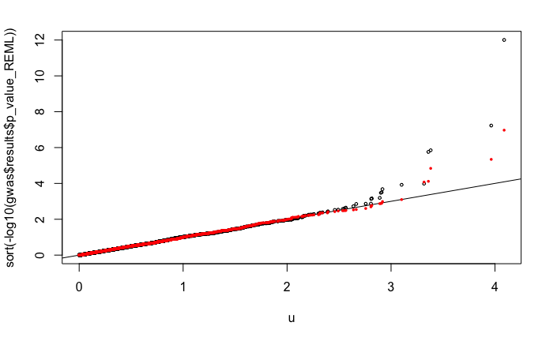

```r
u = sort(-log10(runif(nrow(gwas$results))))
plot(sort(-log10(gwas$results$p_value_REML))~u,pch=21,cex=.5);abline(0,1)
points(sort(-log10(gwas1$results$p_value_REML))~u,pch=21,cex=.5,bg=2,col=NULL)
```

## Run GWAS for GxE using K_g and K_gxe

This is following the idea from here:http://journals.plos.org/plosgenetics/article?id=10.1371/journal.pgen.1005849 that suggested that just as you correct for genetic background with K = X %*% t(X) / ncol(X), you can also correct for GxE background

```r
# add a random environmental vector to data
data$env = rnorm(nrow(data))
gxe_gwas = GridLMM_GWAS_fast(
                        formula = y~1 + env + (1 + env|Geno), # the same error model is used for each marker. It is specified similarly to lmer
                        test_formula = ~1 + env, # this is the model for each marker. ~1 means an intercept for the marker. ~1 + cov means an intercept plus a slope on `cov` for each marker
                        reduced_formula = ~1, # This is the null model for each test. ~0 means just the error model. ~1 means the null includes the intercept of the marker, but not anything additional
                        data = data, # The dataframe to look for terms from the 3 models
                        weights = NULL, # optional observation-specific weights
                        X = X, # The matrix of markers. Note: This can be of dimension n_g x p, where n_g is the number of unique genotypes.
                        X_ID = 'Geno', # The column of the data that identifies each genotype. Each level of data$Geno should match a rowname of X
                        h2_start = NULL, # An optional vector of h2s to use as starting values for each random effect in the model. If NULL, will be calculated from the error model using relmatLmer
                        h2_step = 0.01, # step size per random effect for testing alternate values of h2
                        max_steps = 100, # maximum number of steps of size h2_step to take from h2_start
                        X_map = map, # Optional. The marker positions.
                        relmat = NULL, # A list of Kernel matrices for the random effects. If X_ID (here Geno) is not included in this list, then it is calculated as tcrossprod(Xc)/ncol(Xc) where Xc is the centered (and optionally scaled) X. If any random effects are described in `error_model` but not provided here, the Kernel is assumed to be the identity matrix
                        centerX = TRUE, # Should the markers be centered when calculating the GRM (only will be done if needed for calculating the GRM),
                        scaleX = FALSE, # Should the markers be scaled to have constant variance when calculating the GRM?
                        fillNAX = FALSE, # Should missing marker data be filled in with the mean allele frequency?
                        method = 'REML', # Should the best model be selected by REML (if False, will be selected by ML)
                        mc.cores = 1, # How many cores should be used for parallel processing. Unless X is large, tends to actually be faster with mc.cores = 1
                        verbose = TRUE # Should progress be printed to the screen?
)
```

```
[1] "making RRM matrix"
[1] "Estimating h2_start via null model"
[1] "step_size: 0.5, num_to_test: 3"
[1] "step_size: 0.25, num_to_test: 5"
[1] "step_size: 0.125, num_to_test: 5"
[1] "step_size: 0.0625, num_to_test: 5"
[1] "step_size: 0.0625, num_to_test: 1"
[1] "step_size: 0.03125, num_to_test: 8"
[1] "step_size: 0.03125, num_to_test: 1"
[1] "step_size: 0.015625, num_to_test: 10"
[1] "step_size: 0.015625, num_to_test: 1"
[1] "step_size: 0.0078125, num_to_test: 10"
[1] "step_size: 0.0078125, num_to_test: 1"
[1] "step_size: 0.00390625, num_to_test: 10"
[1] "step_size: 0.00390625, num_to_test: 2"
```

[output cut: 27 more lines]

The GxE p-values are in the slot `p_value_ML`, or `p_value_REML.2`. The slot `p_value_REML.1` contains the p-values for the genotype main effect.

qq-plots

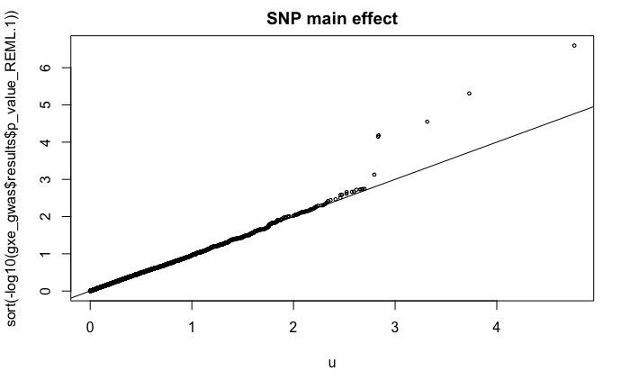

```r
u = sort(-log10(runif(nrow(gxe_gwas$results))))
plot(sort(-log10(gxe_gwas$results$p_value_REML.1))~u,pch=21,cex=.5,main = 'SNP main effect');abline(0,1)
```

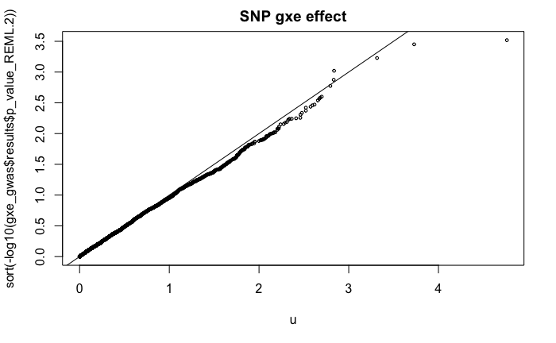

```r
plot(sort(-log10(gxe_gwas$results$p_value_REML.2))~u,pch=21,cex=.5,main = 'SNP gxe effect');abline(0,1)
```